# PCFL 2021: Week 2 wrap-up

### Last week’s games

| Away | Away points | Home | Home points |
| --- | --- | --- | --- |
| Athens Team Sasquatch | 115.56 | KC Gophers | 103.42 |
| Georgia Peanuts | 89.62 | Middle Earth Hangry Hobbits | 139.36 |
| The G.O.A.T. | 83.03 | Jumpin’ Jaheims | 109.58 |
| Southern Sharks | 106.80 | The Sophomores TSoph | 108.60 |
| Captain Clairvoyant | 109.74 | Pigskin on the Gridiron | 144.32 |

The ownership at Peanuts HQ is definitely showing some concern after two weeks of poor showings. This week my intrepid players were thrown into Mount Doom by a dominant performance from Scott’s Hangry Hobbits. That tragic loss in last year’s championship still haunts us. In other news, Evan’s Jaheim’s leaped over the GOAT. In a bitter family faceoff, The Sophomores harpooned the Sharks by just 2 points. Team Sasquatch knocked the Gophers from last year’s high scoring performance. Richard was the high scoring team of the week, downing Brian’s Captain Clairvoyant.

#### Best performing players

Here’s last week’s **10 best performing players.**

| Player | Points | Team |
| --- | --- | --- |
| Derrick Henry | 44.70 | Middle Earth Hangry Hobbits |
| Aaron Jones | 38.50 | Athens Team Sasquatch |
| Kyler Murray | 33.10 | Athens Team Sasquatch |
| Cooper Kupp | 32.30 | Pigskin on the Gridiron |
| Lamar Jackson | 32.26 | Middle Earth Hangry Hobbits |
| Tom Brady | 29.64 | Captain Clairvoyant |
| Daniel Jones | 29.46 | Middle Earth Hangry Hobbits |
| Tyler Lockett | 28.80 | Jumpin’ Jaheims |
| Aaron Rodgers | 26.80 | The Sophomores TSoph |
| Tony Pollard | 25.05 | Southern Sharks |

Not a big fan of Alabama players, but Derrick Henry had a week, following by a fellow running back Aaron Jones. Team Sasquatch and the Hangry Hobbits both had some top scorers.

#### Best addition and top bench

There were 11 players added last week. Which was the **best new addition**?

| Date added | Name | Points | Team |
| --- | --- | --- | --- |
| 2021-09-16 | Henry Ruggs III | 22.10 | Athens Team Sasquatch |
| 2021-09-15 | Rob Gronkowski | 17.90 | Athens Team Sasquatch |
| 2021-09-16 | Tyrod Taylor | 16.50 | Jumpin’ Jaheims |
| 2021-09-15 | Latavius Murray | 9.60 | Georgia Peanuts |
| 2021-09-15 | Deonte Harris | 9.30 | Georgia Peanuts |
| 2021-09-16 | Jameis Winston | 8.34 | KC Gophers |
| 2021-09-15 | Elijah Mitchell | 6.30 | Georgia Peanuts |
| 2021-09-19 | Emmanuel Sanders | 5.80 | Captain Clairvoyant |
| 2021-09-15 | Saints D/ST | 5.00 | Southern Sharks |
| 2021-09-15 | Justin Fields | 3.50 | Athens Team Sasquatch |
| 2021-09-16 | Cardinals D/ST | -2.00 | Jumpin’ Jaheims |

Team Sasquatch had some nice pickups, though I honestly had to look up Henry Ruggs III.

Who won the **best scoring bench** award last week?

| Team | Points |
| --- | --- |
| Pigskin on the Gridiron | 102.58 |
| Middle Earth Hangry Hobbits | 87.48 |
| The Sophomores TSoph | 86.98 |
| Southern Sharks | 85.45 |
| KC Gophers | 78.34 |
| Athens Team Sasquatch | 72.26 |
| Jumpin’ Jaheims | 68.40 |
| The G.O.A.T. | 67.92 |
| Captain Clairvoyant | 51.92 |
| Georgia Peanuts | 49.32 |

Richard won his game with points to spare, with the top bench by 15 points. He’s looking dominant!

### League standings and season stats

Here’s a look at the current standings.

| Team | Division | W | L | Points scored | Points allowed | Points rank | Playoff rank |
| --- | --- | --- | --- | --- | --- | --- | --- |
| Pigskin on the Gridiron | Grits | 2 | 0 | 278.68 | 213.66 | 1 | 1 |
| The Sophomores TSoph | Hot Dish | 2 | 0 | 220.52 | 201.40 | 7 | 2 |
| KC Gophers | Hot Dish | 1 | 1 | 252.70 | 251.32 | 2 | 3 |
| Captain Clairvoyant | Grits | 1 | 1 | 247.00 | 273.88 | 3 | 4 |
| Athens Team Sasquatch | Grits | 1 | 1 | 245.12 | 240.68 | 4 | 5 |
| Middle Earth Hangry Hobbits | Hot Dish | 1 | 1 | 233.96 | 201.54 | 6 | 6 |
| Jumpin’ Jaheims | Grits | 1 | 1 | 213.50 | 217.39 | 8 | 7 |
| Georgia Peanuts | Hot Dish | 1 | 1 | 170.90 | 215.43 | 9 | 8 |
| Southern Sharks | Hot Dish | 0 | 2 | 242.56 | 257.88 | 5 | 9 |
| The G.O.A.T. | Grits | 0 | 2 | 159.10 | 190.86 | 10 | 10 |

Here’s our current awards leaders from these standings:

- Yellow shirt (most points): Pigskin on the Gridiron
- D-FENCE (least points allowed): The G.O.A.T.
- Tough luck (points rank - playoff rank): The Southern Sharks–fifth in points but an 0-2 record to show for it.
- Lucky ducks (playoff rank - points rank): The Sophomores–seventh in points, but a 2-0 record!

Here’s a list of the **top five scoring performances** so far this season.

| Team | Week | Points scored | Result |
| --- | --- | --- | --- |
| KC Gophers | 1 | 149.28 | W |
| Pigskin on the Gridiron | 2 | 144.32 | W |
| Middle Earth Hangry Hobbits | 2 | 139.36 | W |
| Captain Clairvoyant | 1 | 137.26 | W |
| Southern Sharks | 1 | 135.76 | L |

KC Gophers holds onto the top spot this week, but Richard isn’t far behind Christine.

### Here’s a look at the **points trendline** for each team.

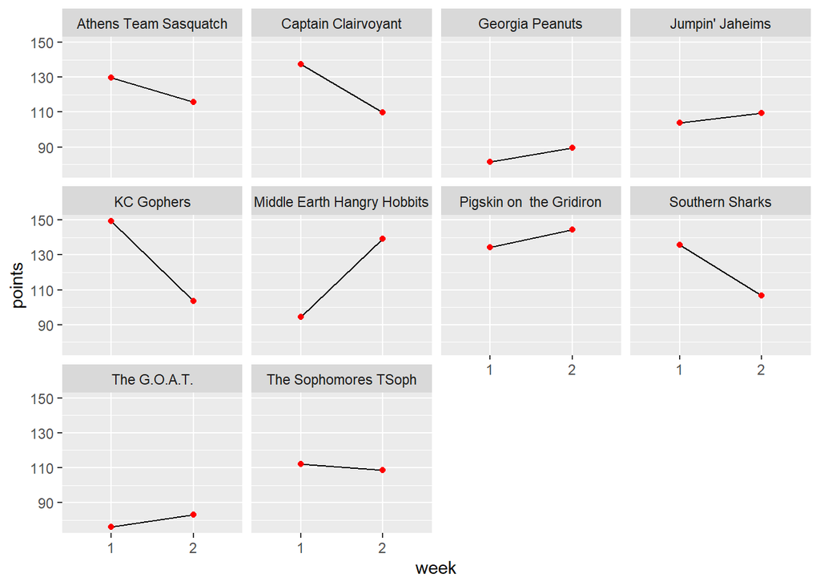

A big jump from the Hangry Hobbits and drops from the Gophers, Sharks, and Captain Clairvoyant. Jacob and I are stuck in mediocrity while Richard stays high.

### If the season ended today…

Our playoff teams would be Richard, Erin/Trav, Christine, and Brian. Our last place finisher would be Jacob. But it’s still early!

### Next week’s preview

| week | game | away_team | away_points | home_team | home_points | range |
| --- | --- | --- | --- | --- | --- | --- |
| 3 | 1 | Jumpin’ Jaheims | 213.50 | Middle Earth Hangry Hobbits | 233.96 | 20.46 |
| 3 | 2 | The Sophomores TSoph | 220.52 | KC Gophers | 252.70 | 32.18 |
| 3 | 3 | Pigskin on the Gridiron | 278.68 | Athens Team Sasquatch | 245.12 | 33.56 |
| 3 | 4 | Southern Sharks | 242.56 | Georgia Peanuts | 170.90 | 71.66 |
| 3 | 5 | Captain Clairvoyant | 247.00 | The G.O.A.T. | 159.10 | 87.90 |

It’s Shannon vs. Shannon as Sarah tries for her first win (and let’s be honest, she’s got a good shot given my season thus far). Last year’s champion, Robbie, tries to cool down Richard’s hot streak as the game of the week. The Sophomores take on the Gophers, and the Jaheims try to leap over the Hobbits. The biggest mismatch of the week on paper is Brian vs. Jacob, with an 88 point spread based on action thus far. But in fantasy, anything can happen!

Good luck, y’all!